# How Propaganda in Russia Works — and How Attention Can Weaken It

Georgiy Syunyaev

g.syunyaev@vanderbilt.edu

Vanderbilt University

## Reach of State TV in Russia

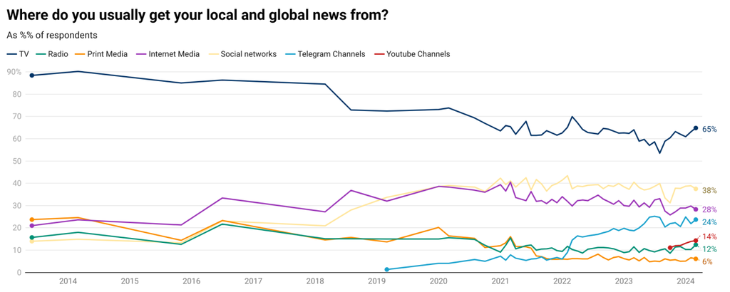

**TV remains a top news source among Russians** (Source: Levada)

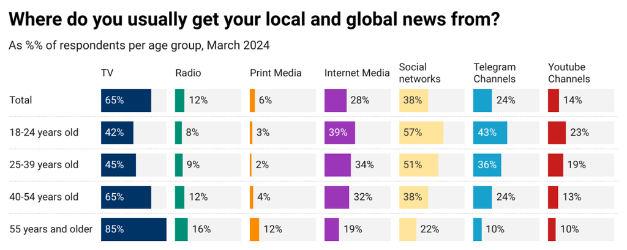

**Younger cohorts diversify, but overall TV reach is resilient** (Source: Levada)

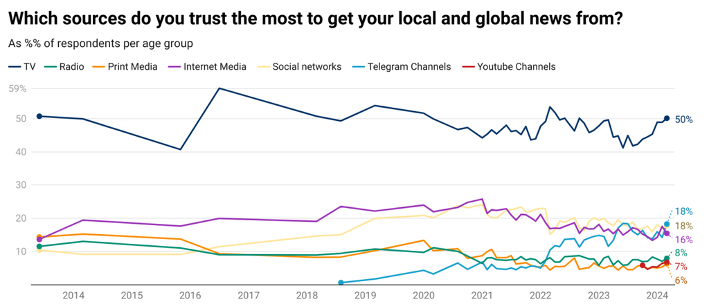

**Trust in TV outpaces other media** (Source: Levada)

$\Rightarrow$ Most citizens still consume propaganda routinely and even trust it

## Two questions

1. **How do citizens in autocracies process information from state vs. non-state sources?**
2. **And how can we affect this processing?**

**Possible answers:**

- Propaganda can persuade both **supporters** and **opponents** via framing and signaling $\Leftarrow$ Effects of TV framing
- The **viable counter**—especially during the wartime—may be to change *how* people watch propaganda rather than *whether* they watch it $\Leftarrow$ Effectiveness of anti-propaganda interventions

## State TV framing as a competence signal

- Study effects of blame-shifting by central government in Russia through state TV
- **Sample:** Online survey in 4 regions of Siberia in late 2019 ($N = 4423$)
- **Treatment:** Rossiya‑1 segments on either roads or wildfires *blame-shifting to local governments*; Comparison to non-political news segment
- **Result:** Responsibility beliefs unchanged, yet policy performance $\Uparrow$ / government support $\Uparrow$

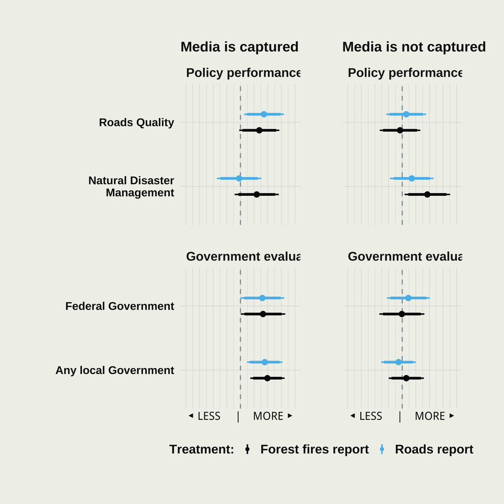

### Are regime supporters more persuaded?

- No! Government evaluations $\Uparrow$ among those who believe Russian media to be captured by the state $\approx$ regime opposers are more persuaded!
- Those who believe media to be unbiased already consume it $\Rightarrow$ prior exposure and less effects of additional exposure

# How to fight propaganda?

## Conventional methods could underperform

- **Offering alternative:** Independent journalism is suppressed; Even before the effectiveness was constrained *(Enikolopov et al. 2023)*
- **Opinion‑leader appeals:** persuasive **mainly when messengers have topical expertise**; otherwise limited *(DeSisto et al. 2024)*
- **Direct citizen‑to‑citizen interaction:** Effects are **small at scale** *(Minson et al. 2024)*
- **Media literacy interventions:** Sometimes work, but often fail or backfire, especially where citizens do not trust the opposition *(Badrinathan 2021)*
- **Our argument:** Offering alternatives and expertise struggle under repression $\Rightarrow$ target how people watch
  - This avoids relying on *others’ judgment/expertise* and possibly attributing evidence to their political agenda

## Drawing attention to political coverage patterns

- Study effects of attentiveness to political news *(co-authored with Anton Shirikov)*
- **Sample:** 4-wave online panel study in late 2023 ($N = 1176$)
- **Treatment:** At the end of waves 1–3 ask respondent to analyze 4–6 evening news headline segments from a combination of three TV channels:
  - **Rossiya-1** – the main state propaganda channel
  - **RTVI** – a private channel with balanced editorial policy
  - **Kultura** – a non-political channel that covers art, theater, architecture, etc.
- **Content analysis focus:** After each video, ask to count *[events in Russia / in other countries / Russian authoritites]* by *[ negative/positive ]* tone

## From attention to learning and consumption?

- Do Russians notice differences in news coverage strategies? **Yes**
  - State media is more positive about Russia/Russian gov’t and more negative about other countries
  - Better distinguish between sources of news headlines (Rossiya-1 vs RTVI quiz)
- Do they adjust their media consumption? **Somewhat**
  - Respondents **did not** decrease consumption of state TV
  - Those who were offered balanced alternative doubled the consumption of it $\Rightarrow$ Expansion of media consumption, rather than shifting

[figure not shown]

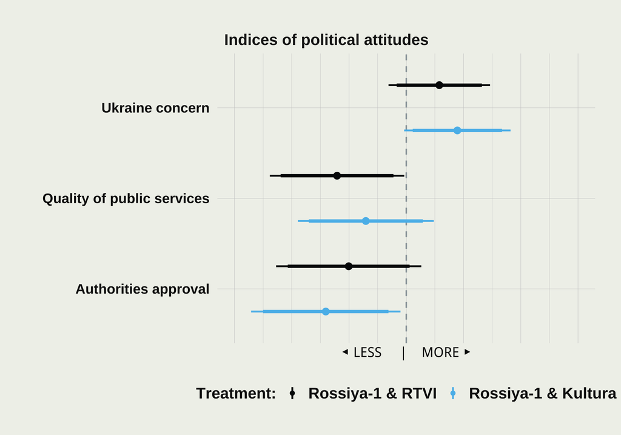

### Did attention to news change political attitudes?

**Yes**: Lower support for the government and stronger concerns about Ukraine; Happens *even* after exposure to Rossiya-1 coverage only!

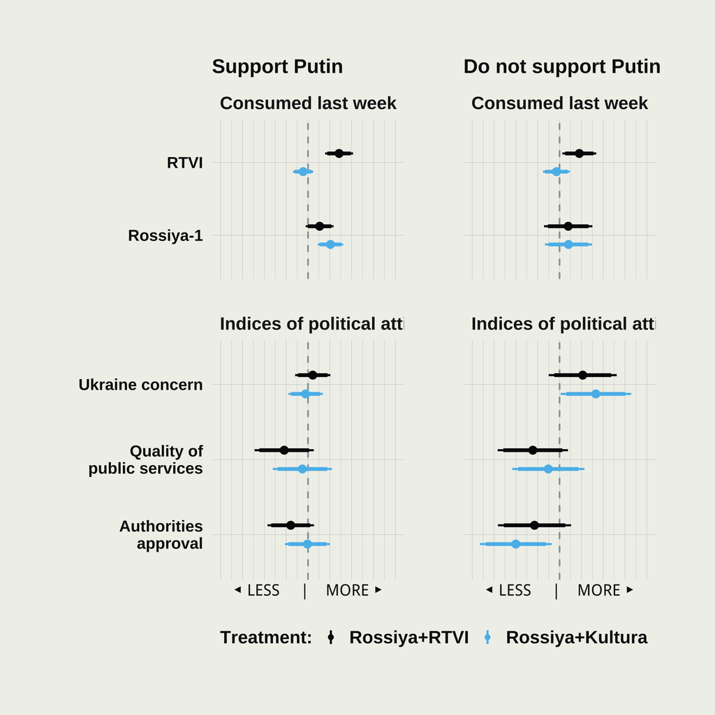

### Does this work better on regime sceptics?

- Yes! Approval of authorities $\Downarrow$ / concern about Ukraine $\Uparrow$ among Putin non-supporters
- But government evaluations also $\Downarrow$ among regime supporters who analyzed new balanced media

## Takeaways

- Simply asking Russians to pay attention to what state and independent media covers **can** lead to change in political attitudes
- This happens even if state TV consumption remains stable $\Rightarrow$ likely the change in **how** media is consumed
- Those who are *more* critical of the government are more affected
  - Attention-prompting might need to be combined with other techniques (e.g. offering alternative media) to change attitudes of regime supporters

## Practical takeaways

- **Conventional counters** (Independent media access, mass emails, expert appeals) have **(at best) modest effects** under wartime repression
- **Attention prompting**—simple, contrastive analysis tasks—**reduces persuasion inside the propaganda bubble** and can aid media diet diversification
- **Targeting matters:** effects larger among **skeptical/non‑loyalists**; core loyalists remain hard to move

## References

Badrinathan, Sumitra. 2021. “Educative Interventions to Combat Misinformation: Evidence from a Field Experiment in India.” *American Political Science Review* 115 (4): 1325–41. https://doi.org/10.1017/s0003055421000459.

DeSisto, Isabelle, Laura Howells, Grigore Pop-Eleches, and Jacob Tucker. 2024. “Countering Authoritarian Propaganda: Perceived Expertise and Persuasiveness.”

Enikolopov, Ruben, Michael Rochlitz, Koen J. L. Schoors, and Nikita Zakharov. 2023. “The Effect of Independent Online Media in an Autocracy.” https://doi.org/10.2139/ssrn.4346225.

Minson, Julia, Aaron Erlich, Christopher Higgins, et al. 2024. “Sharing Accurate News in the Face of Government Repression: A ‘Mega-Study’ in Wartime Russia.”

# Attentiveness study sample

## Where do Russian get their news from?

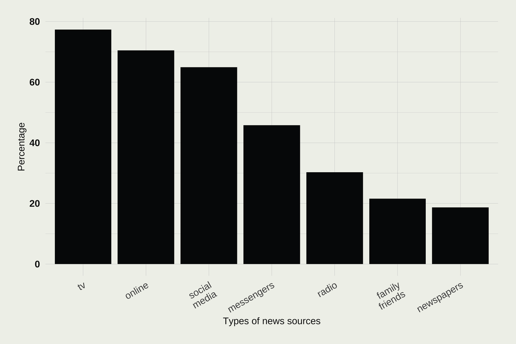

## Where do Russian get their news from?

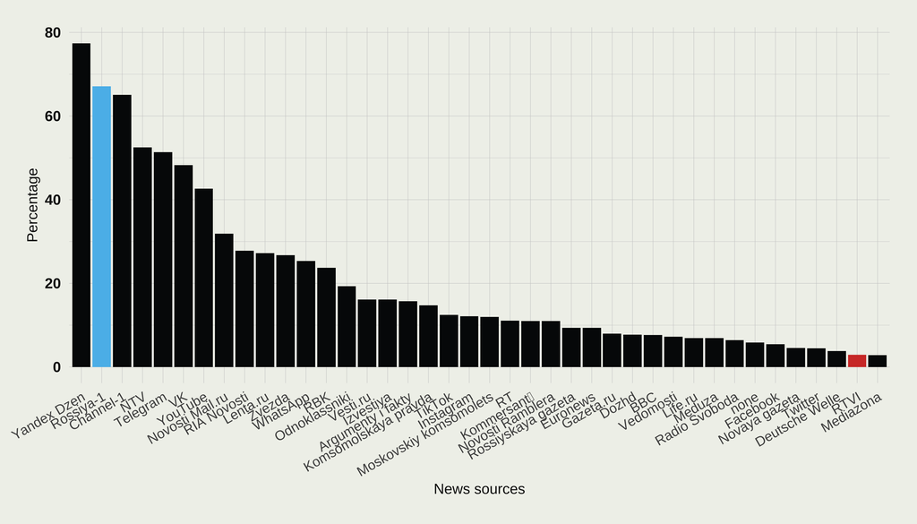

## Why do they choose state media?

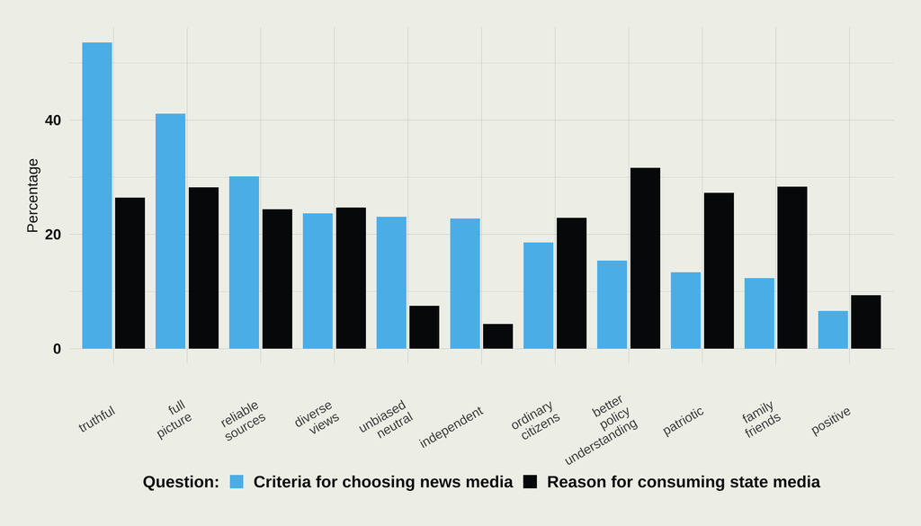

## How do they feel about government?

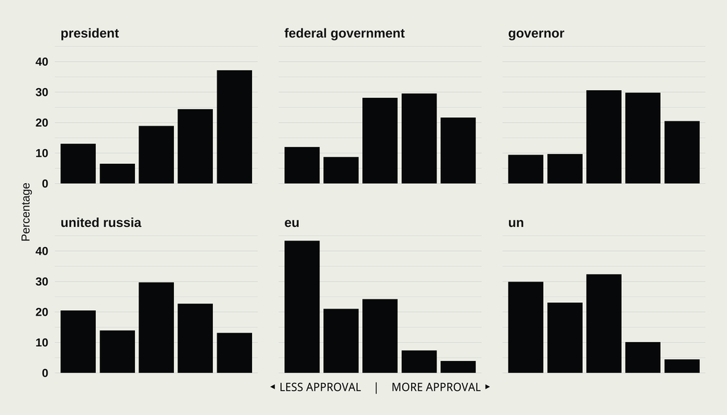

## What about effort government spends on policies?

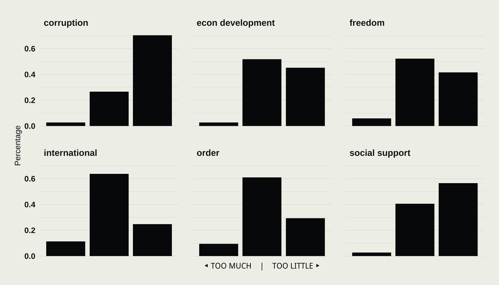